# ML Algorithms for classification

Decision trees

Hicham Zmarrou

Notebook – http://bit.ly/2q9NPSU

[Visit my website](http://trefoil.ml/) for more like this!

**References**

Most of this material is borrowed from:

- Textbook: [Introduction to statistical learning](http://www-bcf.usc.edu/~gareth/ISL/)

```r
url <- 'https://archive.ics.uci.edu/ml/machine-learning-databases/wine-quality/winequality-white.csv'
wine <- read.csv(url, sep = ";")
head(wine)
```

| fixed.acidity | volatile.acidity | citric.acid | residual.sugar | chlorides | free.sulfur.dioxide | total.sulfur.dioxide | density | pH | sulphates | alcohol | quality |
| --- | --- | --- | --- | --- | --- | --- | --- | --- | --- | --- | --- |
| 7.0 | 0.27 | 0.36 | 20.7 | 0.045 | 45 | 170 | 1.0010 | 3.00 | 0.45 | 8.8 | 6 |
| 6.3 | 0.30 | 0.34 | 1.6 | 0.049 | 14 | 132 | 0.9940 | 3.30 | 0.49 | 9.5 | 6 |
| 8.1 | 0.28 | 0.40 | 6.9 | 0.050 | 30 | 97 | 0.9951 | 3.26 | 0.44 | 10.1 | 6 |
| 7.2 | 0.23 | 0.32 | 8.5 | 0.058 | 47 | 186 | 0.9956 | 3.19 | 0.40 | 9.9 | 6 |
| 7.2 | 0.23 | 0.32 | 8.5 | 0.058 | 47 | 186 | 0.9956 | 3.19 | 0.40 | 9.9 | 6 |
| 8.1 | 0.28 | 0.40 | 6.9 | 0.050 | 30 | 97 | 0.9951 | 3.26 | 0.44 | 10.1 | 6 |

Let us look at the distribution of the wine quality. We can use barplot for this.

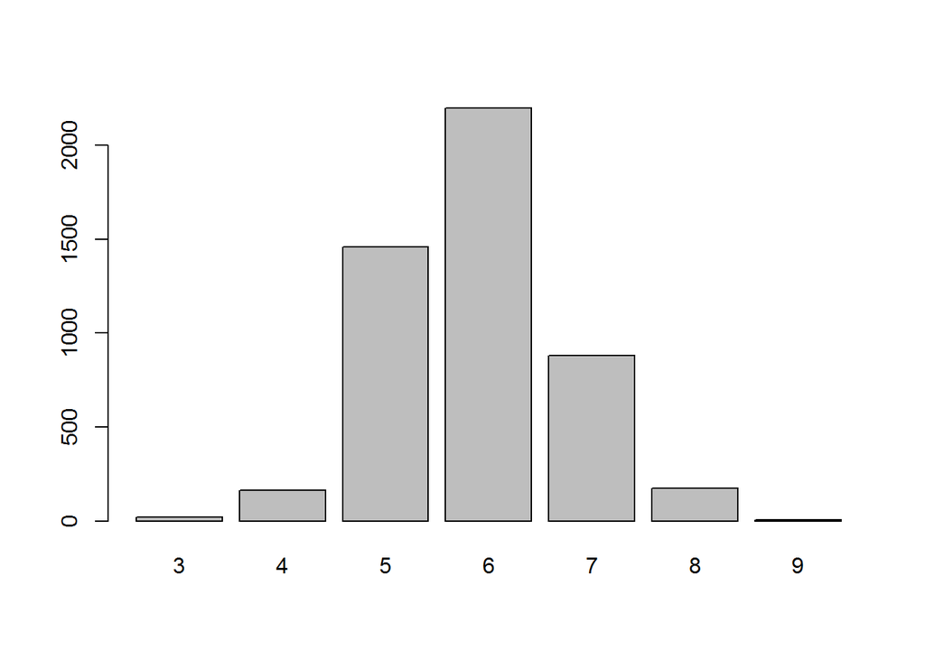

```r
barplot(table(wine$quality))
```

As we can see, there are a lot of wines with a quality of 6 as compared to the others. The dataset description states - there are a lot more normal wines than excellent or poor ones. For the purpose of this discussion, let’s classify the wines into good, bad, and normal based on their quality.

```r
wine$taste <- ifelse(wine$quality < 6, 'bad', 'good')
wine$taste[wine$quality == 6] <- 'normal'
wine$taste <- as.factor(wine$taste)
```

This will classify all wines into bad, normal, or good, depending on whether their quality is less than, equal to, or greater than 6 respectively. Let’s look at the distribution again.

```r
table(wine$taste)
```

```
##
##    bad   good normal
##   1640   1060   2198
```

Before we build our model, let’s separate our data into testing and training sets.

```r
set.seed(123)
samp <- sample(nrow(wine), 0.6 * nrow(wine))
train <- wine[samp, ]
test <- wine[-samp, ]
```

This will place 60% of the observations in the original dataset into train and the remaining 40% of the observations into test.

## Building the model

Now, we are ready to build our model. We will need the randomForest library for this.

```r
library(randomForest)
model <- randomForest(taste ~ . - quality, data = train)

model
```

```
##
## Call:
##  randomForest(formula = taste ~ . - quality, data = train)
##                Type of random forest: classification
##                      Number of trees: 500
## No. of variables tried at each split: 3
##
##         OOB estimate of  error rate: 29.82%
## Confusion matrix:
##        bad good normal class.error
## bad    671   18    284   0.3103803
## good    17  402    230   0.3805855
## normal 221  106    989   0.2484802
```

We can use ntree and mtry to specify the total number of trees to build (default = 500), and the number of predictors to randomly sample at each split respectively. Let’s take a look at the model.

We can see that 500 trees were built, and the model randomly sampled 3 predictors at each split. It also shows a matrix containing prediction vs actual, as well as classification error for each class. Let’s test the model on the test data set.

```r
pred <- predict(model, newdata = test)
table(pred, test$taste)
```

```
##
## pred     bad good normal
##   bad    481   12    128
##   good    13  247     81
##   normal 173  152    673
```

We can test the accuracy as follows:

```r
(482 + 252 + 667) / nrow(test)
```

```
## [1] 0.7147959
```

There we have it! We achieved ~71.5% accuracy with a very simple model. It could be further improved by feature selection, and possibly by trying different values of mtry.

That brings us to the end of the article. I hope you enjoyed it! As always, if you have questions or feedback, feel free to reach out to me on Twitter or leave a comment below!

### Exercies

type help(RandomForest) and read the description of the different parameters of this function